# Coding POMP models: R vs C snippets

Aaron A. King

23 September 2018

This document was produced using **pomp** version 2.0.3.0 and **R** version 3.5.1.

To implement models in **pomp**, we have various options. While it is very easy to code basic model components using **R** functions, it can be much faster to do it using C snippets. Here, we’ll demonstrate both approaches.

First, we’ll load some packages.

```r
library(pomp2)
library(ggplot2)
library(magrittr)
```

The Gompertz model is a very simple partially observed Markov process (POMP) model that we’ll use to demonstrate.

The latent state variable, $X$ represents the density of a population of biological organisms. The state equation is
$$X_{t+\delta} = K^{1-S}\,X_{t}^S\,\epsilon_{t},$$
where $S=e^{-r\,\delta}$ is a parameter and the $\epsilon_t$ are i.i.d. lognormal random deviates with variance $\sigma^2$:
$$\epsilon_t \sim \mathrm{Lognormal}(0,\sigma).$$
The observed variables $Y_t$ are lognormally distributed:
$$Y_t \sim\mathrm{Lognormal}(\log{X_t},\tau).$$

## Implementation using **R** functions

To begin with, we’ll code the latent state process model and both components of the measurement model using **R** functions.

```r
simulate(times=1:100,t0=0,
  params=c(K=1,r=0.1,sigma=0.1,tau=0.1,X.0=1),
  rprocess=discrete_time(
    step.fun=function (X,r,K,sigma,...,delta.t) {
      eps <- exp(rnorm(n=1,mean=0,sd=sigma))
      S <- exp(-r*delta.t)
      c(X=K^(1-S)*X^S*eps)
    },
    delta.t=1
  ),
  rmeasure=function (X, tau, ...) {
    c(Y=rlnorm(n=1,meanlog=log(X),sdlog=tau))
  },
  dmeasure=function (tau, X, Y, ..., log) {
    dlnorm(x=Y,meanlog=log(X),sdlog=tau,log=log)
  },
  partrans=parameter_trans(
    toEst=function(r,K,sigma,tau,X.0,...){
      log(c(r=r,K=K,sigma=sigma,tau=tau,X.0=X.0))
    },
    fromEst=function(r,K,sigma,tau,X.0,...){
      exp(c(r=r,K=K,sigma=sigma,tau=tau,X.0=X.0))
    }
  )
) -> gompertz
```

We plot the results.

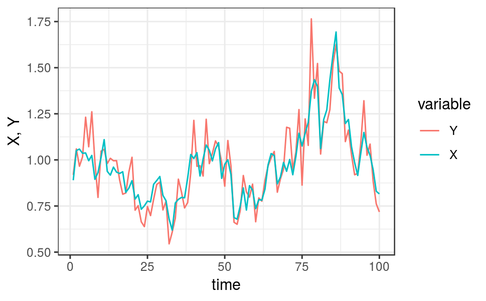

```r
gompertz %>%
  as.data.frame() %>%
  melt(id="time") %>%
  ggplot(aes(x=time,y=value,color=variable))+
  geom_line()+
  labs(y="X, Y")+
  theme_bw()
```

## Implementation using C snippets

Now we’ll code up the same example using C snippets.

```r
simulate(times=0:100,t0=0,
  params=c(K=1,r=0.1,sigma=0.1,tau=0.1,X.0=1),
  dmeasure=Csnippet("
    lik = dlnorm(Y,log(X),tau,give_log);"
  ),
  rmeasure=Csnippet("
    Y = rlnorm(log(X),tau);"
  ),
  rprocess=discrete_time(
    step.fun=Csnippet("
    double S = exp(-r*dt);
    double logeps = (sigma > 0.0) ? rnorm(0,sigma) : 0.0;
    X = pow(K,(1-S))*pow(X,S)*exp(logeps);"
    ),
    delta.t=1
  ),
  partrans=parameter_trans(log=c("r","K","sigma","tau","X.0")),
  paramnames=c("r","K","sigma","X.0","tau"),
  obsnames="Y",
  statenames="X"
) -> Gompertz
```

## Testing the implementations

Having coded the model, it’s a good idea to run some simple tests to check the implementation. We can run simulations and a particle filter operation to check that the *rprocess*, *rmeasure*, and *dmeasure* components function without error.

First, some simulations, from several initial conditions:

```r
p <- parmat(coef(Gompertz),4)
p["X.0",] <- c(0.5,0.9,1.1,1.5)
```

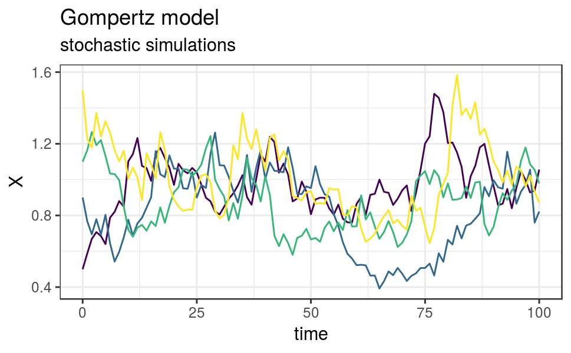

```r
simulate(Gompertz,params=p,format="data.frame") %>%
  ggplot(aes(x=time,y=X,group=.id,color=.id))+
  geom_line()+
  guides(color=FALSE)+
  theme_bw()+
  labs(title="Gompertz model",subtitle="stochastic simulations")
```

We run 10 replicate particle filter operations at the true parameter values as follows. This allows us to assess the Monte Carlo error in the likelihood estimate.

```r
pf <- replicate(n=10,pfilter(Gompertz,Np=500))

logmeanexp(sapply(pf,logLik),se=TRUE)
```

```
##                    se
## 62.8137837  0.1679958
```

## Comparing the implementations

Using each implementation, we’ll now run a number of simulations and compare the amount of time required.

```r
system.time(simulate(gompertz,nsim=10000,format="arrays"))
```

```
##    user  system elapsed
##   6.972   0.012   6.984
```

```r
system.time(simulate(Gompertz,nsim=10000,format="arrays"))
```

```
##    user  system elapsed
##   0.340   0.004   0.344
```

```r
system.time(pfilter(gompertz,Np=10000))
```

```
##    user  system elapsed
##   5.864   0.000   5.863
```

```r
system.time(pfilter(Gompertz,Np=10000))
```

```
##    user  system elapsed
##   0.368   0.000   0.370
```

**pomp** vignette index